# Pathway Analysis w/ MSigDB

D. Ford Hannum

2025-06-24

```r
knitr::opts_chunk$set(echo = TRUE, message = FALSE)

# Set the directory to where everything is located
knitr::opts_knit$set(root.dir = '/Users/dfhannum/Desktop/OphthalmApp/') # sets it for all code chunks

library(Seurat) # for scRNA functions and plots
library(ggplot2) # for custom plotting
library(data.table) # data file processing and tstrsplit
library(clusterProfiler) # pathway analysis
library(org.Mm.eg.db) # <org.Hs.eg.db> human or <org.Rn.eg.db> rat
library(msigdbr) # access to MSigDB
```

# 1 Introduction

In this document we are going to use an already created Seurat scRNA object. We are then going to identify differentially expressed genes between conditions within clusters, and submit those markers for over-representation (enrichment) analysis with MSigDB. We will then make some plots representing the most significant pathways.

# 2 Data

I’m using a previously published dataset that I’ve reanalyzed for other example scripts.

```r
# Loading in the data
obj <- readRDS('./data/seurat_obj_full.Rds')
```

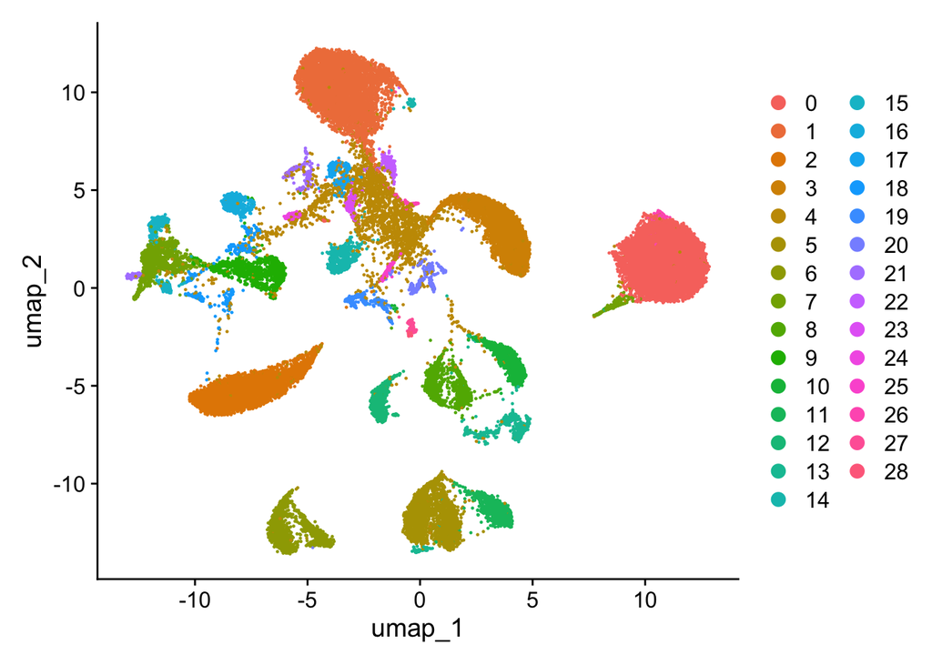

```r
# Visualizing the data
DimPlot(obj)
```

We are going to rerun the clustering to identify a smaller number of clusters. Many of these clusters will share similar transcriptomic profiles. For the speed/visualizations of my downstream example it’ll be easier working with fewer clusters.

```r
obj <- FindClusters(obj, resolution = .05)
```

```
## Modularity Optimizer version 1.3.0 by Ludo Waltman and Nees Jan van Eck
##
## Number of nodes: 36827
## Number of edges: 1171837
##
## Running Louvain algorithm...
## Maximum modularity in 10 random starts: 0.9915
## Number of communities: 14
## Elapsed time: 4 seconds
```

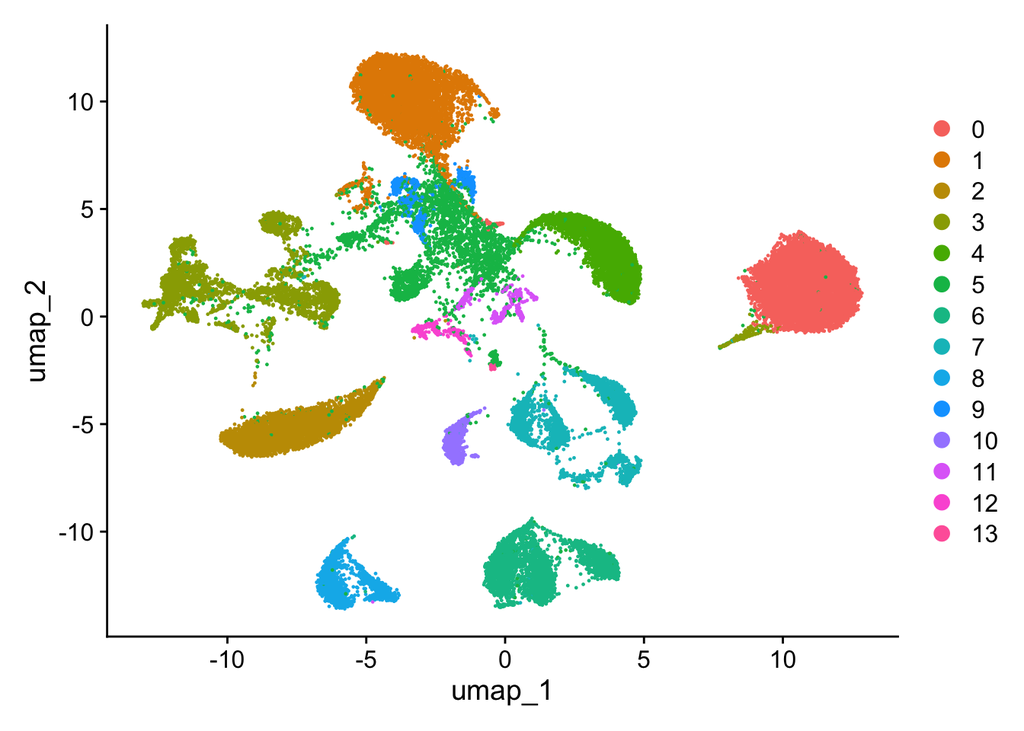

```r
# Projecting the data in umap space
DimPlot(obj)
```

We can also look at the umap for mutant and WT separately.

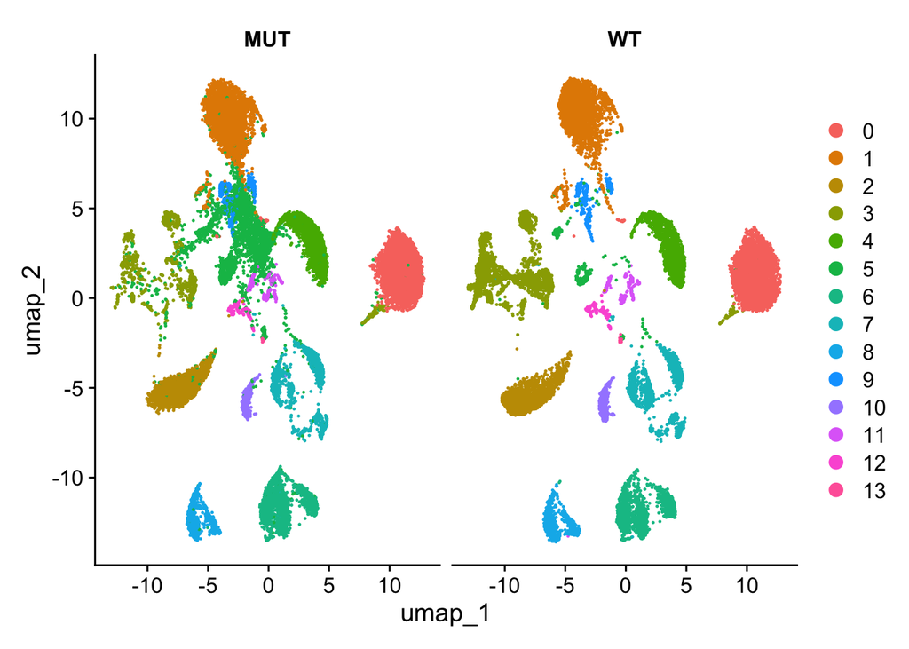

```r
DimPlot(obj, split.by = 'orig.ident')
```

# 3 Finding Condition DEGs within Clusters

We will calculate differentially expressed genes between conditions for each cluster.

We can create a new variable that combines our condition (orig.ident for this data) and cluster.

```r
table(Idents(obj),
      obj$orig.ident)
```

```
##
##       MUT   WT
##   0  4001 3425
##   1  2980 2365
##   2  2128 1675
##   3   971 2802
##   4  1846 1579
##   5  2898  306
##   6  1642 1430
##   7  1208 1470
##   8   772  806
##   9   506  320
##   10  372  396
##   11  285  216
##   12  203  160
##   13   39   26
```

```r
obj$cond_by_cluster <- paste0(obj$orig.ident,'_', Idents(obj))
```

```r
# Creating empty list
results <- list()

# Looping through clusters
for (cluster in levels(Idents(obj))){
  # print(cluster)

  markers <- FindMarkers(object = obj,
                         test.use = 'wilcox',
                         group.by = 'cond_by_cluster', # variable to group by
                         ident.1 = paste0('WT_',cluster), # wt in cluster
                         ident.2 = paste0('MUT_',cluster), # mut in cluster
                         logfc.threshold = .2) # a fc threshold to limit to sig. results and to run faster

  # Adding it to the results list
  results[[paste0('c', cluster)]] <- markers
}
```

## 3.1 Alternative

If you have more than one condition the above code will not work. Here you’ll need to decide if you’re running one genotype vs all others (ex. geno1 vs geno2 + geno3) or in a pairwise manner (ex. geno1 vs geno2, geno1 vs geno3).

For the one vs all others the below code should work instead of the previous code chunk.

```r
# Creating a new random variable with three genotypes by cluster
obj$geno <- sample(c('geno1','geno2','geno3'), dim(obj)[2], replace = T)

results2 <- list()

# demo'ing through one cluster
for (i in levels(Idents(obj))){
  print(i)
  for (geno in unique(obj$geno)){
    # This pulls compares geno1 to geno2 & geno3 within cluster i
    obj$temp_label <- ifelse(obj$seurat_clusters != i, 'other',
                             ifelse(obj$geno == geno, geno,
                                    'other_geno'))

    markers <- FindMarkers(obj,
                           group.by = 'temp_label',
                           ident.1 = geno,
                           ident.2 = 'other_geno',
                           logfc.threshold = .2
                           # ... other params you want to include
                           )

    results2[[paste0('c',i,'_',geno)]] <- markers

  }

  break # breaking out of the for loop
}
```

```
## [1] "0"
```

## 3.2 Extracting DEGs

Next we are going to extract the differentially expressed genes for each cluster

```r
# Creating an empty list to add to
marker_list <- list()

# A for loop to loop through the clusters
# You can replace obj$seurat_clusters with your cluster identity
for (i in names(results)){

  # Print statements are always useful in for loops to track progress and to
  # make sure it's doing what it's suppose to
  # print(paste0())

  # Isolating markers for the given cluster
  temp <- results[[i]]

  # Only keeping significant markers
  temp <- temp[temp$p_val_adj < .05,]

  # Separating up & down markers
  up_markers <- rownames(temp[temp$avg_log2FC > 0,])
  down_markers <- rownames(temp[temp$avg_log2FC < 0,])

  # Printing a statement saying how many markers we have
  print(paste0("Cluster ", substr(i,2,nchar(i)), " contains ", dim(temp)[1], ' markers'))

  if(dim(temp)[1] == 0){
    next
  }

  print(paste0('Up in WT = ',
               length(up_markers)))

  print(paste0('Up in MUT = ',
               length(down_markers)))

  # Adding the markers/gene to the list indexed by cluster
  marker_list[[paste0(i,'_wt')]] <- up_markers
  marker_list[[paste0(i,'_mut')]] <- down_markers
  # break
}
```

```
## [1] "Cluster 0 contains 574 markers"
## [1] "Up in WT = 341"
## [1] "Up in MUT = 233"
## [1] "Cluster 1 contains 1138 markers"
## [1] "Up in WT = 807"
## [1] "Up in MUT = 331"
## [1] "Cluster 2 contains 446 markers"
## [1] "Up in WT = 277"
## [1] "Up in MUT = 169"
## [1] "Cluster 3 contains 2188 markers"
## [1] "Up in WT = 1917"
## [1] "Up in MUT = 271"
## [1] "Cluster 4 contains 287 markers"
## [1] "Up in WT = 146"
## [1] "Up in MUT = 141"
```

[output cut: 25 more lines]

# 4 MSigDB

We will use the molecular signatures database ([MSigDB](https://www.gsea-msigdb.org/gsea/msigdb/)) to load their mouse collections to then run enrichment analysis with clusterProfiler

## 4.1 Database generation

In this chunk of code we will generate the database for use in clusterProfiler.

```r
# Loading all gene sets present in MSigDB for mouse
all_gene_sets <- msigdbr(species = 'Mus musculus')

head(all_gene_sets) # looking at the first six rows of the data
```

```
## # A tibble: 6 × 23
##   gene_symbol ncbi_gene ensembl_gene db_gene_symbol db_ncbi_gene db_ensembl_gene
##   <chr>       <chr>     <chr>        <chr>          <chr>        <chr>
## 1 Abcc4       239273    ENSMUSG0000… ABCC4          10257        ENSG00000125257
## 2 Abraxas2    109359    ENSMUSG0000… ABRAXAS2       23172        ENSG00000165660
## 3 Actn4       60595     ENSMUSG0000… ACTN4          81           ENSG00000130402
## 4 Acvr1       11477     ENSMUSG0000… ACVR1          90           ENSG00000115170
## 5 Adam9       11502     ENSMUSG0000… ADAM9          8754         ENSG00000168615
## 6 Adamts5     23794     ENSMUSG0000… ADAMTS5        11096        ENSG00000154736
## # ℹ 17 more variables: source_gene <chr>, gs_id <chr>, gs_name <chr>,
## #   gs_collection <chr>, gs_subcollection <chr>, gs_collection_name <chr>,
## #   gs_description <chr>, gs_source_species <chr>, gs_pmid <chr>,
## #   gs_geoid <chr>, gs_exact_source <chr>, gs_url <chr>, db_version <chr>,
## #   db_target_species <chr>, ortholog_taxon_id <int>, ortholog_sources <chr>,
## #   num_ortholog_sources <dbl>
```

Next we will look at the different collections in MSigDB.

```r
unique(all_gene_sets$gs_collection_name)[order(unique(all_gene_sets$gs_collection_name))]
```

```
##  [1] "BioCarta Pathways"
##  [2] "Cancer Gene Neighborhoods"
##  [3] "Cancer Modules"
##  [4] "Canonical Pathways"
##  [5] "Cell Type Signature"
##  [6] "Chemical and Genetic Perturbations"
##  [7] "Curated Cancer Cell Atlas gene sets "
##  [8] "GO Biological Process"
##  [9] "GO Cellular Component"
## [10] "GO Molecular Function"
## [11] "GTRD"
## [12] "Hallmark"
## [13] "HIPC Vaccine Response"
## [14] "Human Phenotype Ontology"
## [15] "ImmuneSigDB"
## [16] "KEGG Legacy Pathways"
## [17] "KEGG Medicus Pathways"
## [18] "MIR_Legacy"
## [19] "miRDB"
## [20] "Oncogenic Signature"
## [21] "PID Pathways"
## [22] "Positional"
## [23] "Reactome Pathways"
## [24] "TFT_Legacy"
## [25] "WikiPathways"
```

More details about the collections are available.

```r
head(msigdbr_collections())
```

```
## # A tibble: 6 × 4
##   gs_collection gs_subcollection  gs_collection_name                num_genesets
##   <chr>         <chr>             <chr>                                    <int>
## 1 C1            ""                Positional                                 302
## 2 C2            "CGP"             Chemical and Genetic Perturbatio…         3494
## 3 C2            "CP"              Canonical Pathways                          19
## 4 C2            "CP:BIOCARTA"     BioCarta Pathways                          292
## 5 C2            "CP:KEGG_LEGACY"  KEGG Legacy Pathways                       186
## 6 C2            "CP:KEGG_MEDICUS" KEGG Medicus Pathways                      658
```

```r
# Collecting unique rows in the database and creating the term to gene object
msigdbr_t2g <- dplyr::distinct(all_gene_sets, gs_name, gene_symbol)
```

## 4.2 Running enricher

Next we will run the enricher function on the DEGs between conditions. This step will take a while.

```r
pathway_results <- list()
for (i in names(marker_list)){
  print(i)

  res <- enricher(gene = marker_list[[i]], # cluster marker genes
                  TERM2GENE = msigdbr_t2g, # reference database
                  universe = rownames(obj), # background reference list
                  pvalueCutoff = 1)

  pathway_results[[i]] <- res
}
```

```
## [1] "c0_wt"
## [1] "c0_mut"
## [1] "c1_wt"
## [1] "c1_mut"
## [1] "c2_wt"
## [1] "c2_mut"
## [1] "c3_wt"
## [1] "c3_mut"
## [1] "c4_wt"
## [1] "c4_mut"
## [1] "c5_wt"
## [1] "c5_mut"
## [1] "c6_wt"
## [1] "c6_mut"
## [1] "c7_wt"
## [1] "c7_mut"
## [1] "c8_wt"
## [1] "c8_mut"
## [1] "c9_wt"
## [1] "c9_mut"
## [1] "c10_wt"
## [1] "c10_mut"
## [1] "c11_wt"
## [1] "c11_mut"
## [1] "c12_wt"
## [1] "c12_mut"
```

## 4.3 Looking at results for cluster 1

First we will look at the pathways enriched in WT.

### 4.3.1 Enriched in WT

```r
temp <- pathway_results[['c1_wt']]

temp
```

```
## #
## # over-representation test
## #
## #...@organism     UNKNOWN
## #...@ontology     UNKNOWN
## #...@gene     chr [1:807] "Hopx" "Gm42418" "Pmepa1" "Hes5" "Abca8a" "Ptn" "Apoe" "Tenm4" ...
## #...pvalues adjusted by 'BH' with cutoff <1
## #...2400 enriched terms found
## 'data.frame':    2400 obs. of  12 variables:
##  $ ID            : chr  "MANNO_MIDBRAIN_NEUROTYPES_HSERT" "MANNO_MIDBRAIN_NEUROTYPES_HNBML5" "MANNO_MIDBRAIN_NEUROTYPES_HDA" "ZHONG_PFC_C3_MICROGLIA" ...
##  $ Description   : chr  "MANNO_MIDBRAIN_NEUROTYPES_HSERT" "MANNO_MIDBRAIN_NEUROTYPES_HNBML5" "MANNO_MIDBRAIN_NEUROTYPES_HDA" "ZHONG_PFC_C3_MICROGLIA" ...
##  $ GeneRatio     : chr  "83/729" "80/729" "80/729" "79/729" ...
##  $ BgRatio       : chr  "435/17223" "434/17223" "470/17223" "461/17223" ...
##  $ RichFactor    : num  0.191 0.184 0.17 0.171 0.164 ...
##  $ FoldEnrichment: num  4.51 4.35 4.02 4.05 3.87 ...
##  $ zScore        : num  15.6 14.9 14 13.9 13.5 ...
##  $ pvalue        : num  7.84e-32 1.29e-29 3.52e-27 4.78e-27 5.38e-26 ...
##  $ p.adjust      : num  1.78e-27 1.47e-25 2.67e-23 2.72e-23 2.45e-22 ...
##  $ qvalue        : num  1.60e-27 1.31e-25 2.39e-23 2.44e-23 2.19e-22 ...
##  $ geneID        : chr  "Slc4a8/Cadm1/Basp1/Adam22/Ncam1/Tenm2/Cdh13/Kit/Slc24a3/Gng3/Spock1/Grm7/Rasgrp2/Brinp1/Fry/Tafa5/Creg2/Syt1/Kc"| __truncated__ "Basp1/Ncam1/Tenm2/Cdh13/Nmnat2/Tox3/Gng3/Grm7/Ank3/Tagln3/Fry/Nnat/Cntnap2/Auts2/Ctsc/Osbpl6/Xkr4/Rims1/Elavl3/"| __truncated__ "Slc4a8/Cadm1/B…
##  $ Count         : int  83 80 80 79 80 65 59 64 65 55 ...
## #...Citation
##  T Wu, E Hu, S Xu, M Chen, P Guo, Z Dai, T Feng, L Zhou, W Tang, L Zhan, X Fu, S Liu, X Bo, and G Yu.
##  clusterProfiler 4.0: A universal enrichment tool for interpreting omics data.
##  The Innovation. 2021, 2(3):100141
```

```r
# Put it in dataframe form to query and plot
temp <- as.data.frame(temp)

dim(temp)
```

```
## [1] 2400   12
```

```r
head(temp)
```

```
##                                                                ID
## MANNO_MIDBRAIN_NEUROTYPES_HSERT   MANNO_MIDBRAIN_NEUROTYPES_HSERT
## MANNO_MIDBRAIN_NEUROTYPES_HNBML5 MANNO_MIDBRAIN_NEUROTYPES_HNBML5
## MANNO_MIDBRAIN_NEUROTYPES_HDA       MANNO_MIDBRAIN_NEUROTYPES_HDA
## ZHONG_PFC_C3_MICROGLIA                     ZHONG_PFC_C3_MICROGLIA
## MANNO_MIDBRAIN_NEUROTYPES_HDA2     MANNO_MIDBRAIN_NEUROTYPES_HDA2
## MANNO_MIDBRAIN_NEUROTYPES_HOMTN   MANNO_MIDBRAIN_NEUROTYPES_HOMTN
##                                                       Description GeneRatio
## MANNO_MIDBRAIN_NEUROTYPES_HSERT   MANNO_MIDBRAIN_NEUROTYPES_HSERT    83/729
## MANNO_MIDBRAIN_NEUROTYPES_HNBML5 MANNO_MIDBRAIN_NEUROTYPES_HNBML5    80/729
## MANNO_MIDBRAIN_NEUROTYPES_HDA       MANNO_MIDBRAIN_NEUROTYPES_HDA    80/729
## ZHONG_PFC_C3_MICROGLIA                     ZHONG_PFC_C3_MICROGLIA    79/729
## MANNO_MIDBRAIN_NEUROTYPES_HDA2     MANNO_MIDBRAIN_NEUROTYPES_HDA2    80/729
## MANNO_MIDBRAIN_NEUROTYPES_HOMTN   MANNO_MIDBRAIN_NEUROTYPES_HOMTN    65/729
##                                    BgRatio RichFactor FoldEnrichment   zScore
## MANNO_MIDBRAIN_NEUROTYPES_HSERT  435/17223  0.1908046       4.507857 15.57864
## MANNO_MIDBRAIN_NEUROTYPES_HNBML5 434/17223  0.1843318       4.354934 14.88192
## MANNO_MIDBRAIN_NEUROTYPES_HDA    470/17223  0.1702128       4.021364 13.96202
## ZHONG_PFC_C3_MICROGLIA           461/17223  0.1713666       4.048624 13.94871
## MANNO_MIDBRAIN_NEUROTYPES_HDA2   489/17223  0.1635992       3.865115 13.51261
## MANNO_MIDBRAIN_NEUROTYPES_HOMTN  371/17223  0.1752022       4.139241 12.85075
##                                        pvalue     p.adjust       qvalue
## MANNO_MIDBRAIN_NEUROTYPES_HSERT  7.839622e-32 1.784612e-27 1.596230e-27
## MANNO_MIDBRAIN_NEUROTYPES_HNBML5 1.290518e-29 1.468868e-25 1.313816e-25
## MANNO_MIDBRAIN_NEUROTYPES_HDA    3.524495e-27 2.674387e-23 2.392081e-23
## ZHONG_PFC_C3_MICROGLIA           4.784105e-27 2.722634e-23 2.435235e-23
## MANNO_MIDBRAIN_NEUROTYPES_HDA2   5.380054e-26 2.449431e-22 2.190871e-22
## MANNO_MIDBRAIN_NEUROTYPES_HOMTN  6.406153e-23 2.430494e-19 2.173933e-19
##                                                                                                                                                                                                                                                                                                          …
## MANNO_MIDBRAIN_NEUROTYPES_HSERT  Slc4a8/Cadm1/Basp1/Adam22/Ncam1/Tenm2/Cdh13/Kit/Slc24a3/Gng3…
## MANNO_MIDBRAIN_NEUROTYPES_HNBML5                                  Basp1/Ncam1/Tenm2/Cdh13/Nmnat2/Tox3/Gng3/Grm7/Ank3/Tagln3/Fr…
## MANNO_MIDBRAIN_NEUROTYPES_HDA                              Slc4a8/Cadm1/Basp1/Ncam1/Cdh13/Slc24a3/Nmnat2/Gng3/Fat3/Ank3…
## ZHONG_PFC_C3_MICROGLIA                                     Tenm4/Cadm1/Adam22/Ncam1/Tenm2/Phpt1/Gucy1a1/Fat3/Stmn3/Ank3…
## MANNO_MIDBRAIN_NEUROTYPES_HDA2                                  Dkk3/Basp1/Ncam1/Sntg1/Cdh13/Nmnat2/Gng3/Ank3/Fry/Nnat/Creg2…
## MANNO_MIDBRAIN_NEUROTYPES_HOMTN                                                                                                                               Slc4a8/Cadm1/Basp1/Adam22/Tenm2/Mgat5/Nmnat2/Gng3/Stmn3/Ank3…
##                                  Count
## MANNO_MIDBRAIN_NEUROTYPES_HSERT     83
## MANNO_MIDBRAIN_NEUROTYPES_HNBML5    80
## MANNO_MIDBRAIN_NEUROTYPES_HDA       80
## ZHONG_PFC_C3_MICROGLIA              79
## MANNO_MIDBRAIN_NEUROTYPES_HDA2      80
## MANNO_MIDBRAIN_NEUROTYPES_HOMTN     65
```

Here we have the gene set name but not the collection they belong to, so we’ll need to map back to that.

```r
# creating a dataframe with gene sets mapped to their collection name
collections <- as.data.frame(dplyr::distinct(all_gene_sets, gs_name, gs_collection_name))

# # Checking that they all overlap
# table(temp$ID %in% collections$gs_name)

rownames(collections) <- collections$gs_name
temp$collection <- collections[temp$ID,]$gs_collection_name

# Looking at how many entries we have for each collection in our results
table(temp$collection)
```

```
##
##                    BioCarta Pathways            Cancer Gene Neighborhoods
##                                    6                                   11
##                       Cancer Modules                  Cell Type Signature
##                                   26                                  209
##   Chemical and Genetic Perturbations Curated Cancer Cell Atlas gene sets
##                                  337                                   25
##                GO Biological Process                GO Cellular Component
##                                  445                                   72
##                GO Molecular Function                                 GTRD
##                                   75                                    9
##                             Hallmark                HIPC Vaccine Response
##                                   11                                    7
##             Human Phenotype Ontology                          ImmuneSigDB
##                                  156                                  268
##                 KEGG Legacy Pathways                KEGG Medicus Pathways
##                                    9                                   11
##                           MIR_Legacy                                miRDB
##                                   39                                  371
##                  Oncogenic Signature                         PID Pathways
##                                   33                                    8
##                           Positional                    Reactome Pathways
##                                   16                                   69
##                           TFT_Legacy                         WikiPathways
##                                  159                                   28
```

```r
# Looking at the number of significant entries (TRUE) for each collection
table(temp$collection,temp$p.adjust < .05)
```

```
##
##                                        FALSE TRUE
##   BioCarta Pathways                        5    1
##   Cancer Gene Neighborhoods                4    7
##   Cancer Modules                          17    9
##   Cell Type Signature                     83  126
##   Chemical and Genetic Perturbations     215  122
##   Curated Cancer Cell Atlas gene sets     16    9
##   GO Biological Process                  288  157
##   GO Cellular Component                   32   40
##   GO Molecular Function                   54   21
##   GTRD                                     6    3
##   Hallmark                                 9    2
##   HIPC Vaccine Response                    6    1
##   Human Phenotype Ontology               102   54
##   ImmuneSigDB                            228   40
##   KEGG Legacy Pathways                     7    2
##   KEGG Medicus Pathways                    8    3
##   MIR_Legacy                              29   10
##   miRDB                                  277   94
##   Oncogenic Signature                     18   15
##   PID Pathways                             6    2
##   Positional                              13    3
##   Reactome Pathways                       46   23
##   TFT_Legacy                             107   52
##   WikiPathways                            18   10
```

#### 4.3.1.1 WikiPathways Results

Next we’ll view and plot the WikiPathways results, one of the collections in MSigDB.

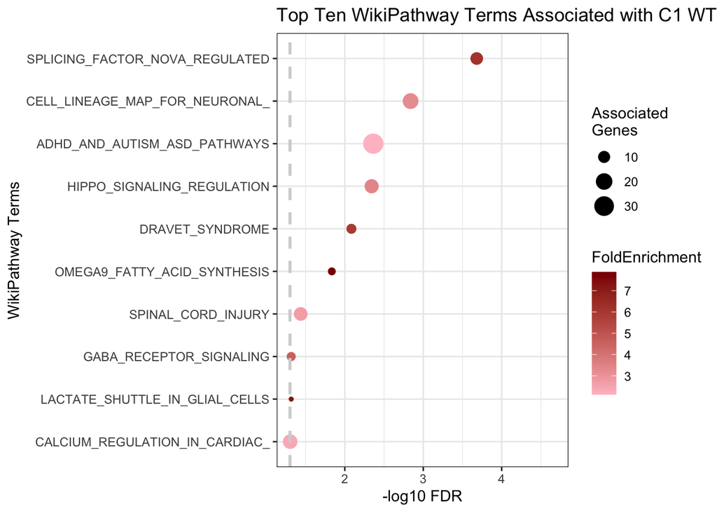

```r
wiki <- temp[temp$collection == 'WikiPathways',] # subsetting to just Wiki results

wiki$id <- gsub('WP_','', wiki$ID) # removing the WP_ preceder from term IDs
wiki$id <- substr(wiki$id,1,30) # limiting to thirty characters for ID bc some get long
wiki$id <- factor(wiki$id, levels = rev(unique(wiki$id))) # ordering them by p-vals

ggplot(wiki[1:10,], # only plotting the first ten
       aes(x = -log10(p.adjust),
           y = id,
           color = FoldEnrichment,
           size = Count)) +
  theme_bw() + # my theme of choice
  geom_point() +
  scale_color_gradient(low = 'pink', high = 'darkred') + # creating a monotonic color scheme
  # creating a significance cutoff to let viewers know all values plotted are significant
  geom_vline(xintercept = -log10(0.05), colour = 'lightgrey', linetype = 2, linewidth = 1) +
  # increasing the xlims because the larger points were getting cut off
  xlim(c(-log10(0.05),-log10(min(wiki$p.adjust)) + 1)) +
  # cleaning up the labels on the graph
  labs(fill = 'Fold\nEnrichment',
       size = 'Associated\nGenes') +
  xlab('-log10 FDR') +
  ylab("WikiPathway Terms") +
  ggtitle("Top Ten WikiPathway Terms Associated with C1 WT")
```

```r
wt_c1 <- wiki[1:10,] # saving to plot with enriched in MUT
```

### 4.3.2 Enriched in MUT

```r
temp <- pathway_results[['c1_mut']]

temp
```

```
## #
## # over-representation test
## #
## #...@organism     UNKNOWN
## #...@ontology     UNKNOWN
## #...@gene     chr [1:331] "Rps29" "Rps27" "Rpl38" "Rps28" "Gm10076" "Gm10260" "Rpl37a" ...
## #...pvalues adjusted by 'BH' with cutoff <1
## #...2692 enriched terms found
## 'data.frame':    2692 obs. of  12 variables:
##  $ ID            : chr  "RUBENSTEIN_SKELETAL_MUSCLE_SATELLITE_CELLS" "GOBP_SENSORY_PERCEPTION_OF_LIGHT_STIMULUS" "JIANG_MELANOMA_TRM8_CD4" "GAVISH_3CA_METAPROGRAM_EPITHELIAL_STRESS" ...
##  $ Description   : chr  "RUBENSTEIN_SKELETAL_MUSCLE_SATELLITE_CELLS" "GOBP_SENSORY_PERCEPTION_OF_LIGHT_STIMULUS" "JIANG_MELANOMA_TRM8_CD4" "GAVISH_3CA_METAPROGRAM_EPITHELIAL_STRESS" ...
##  $ GeneRatio     : chr  "48/275" "36/275" "47/275" "21/275" ...
##  $ BgRatio       : chr  "301/17223" "214/17223" "419/17223" "48/17223" ...
##  $ RichFactor    : num  0.159 0.168 0.112 0.438 0.13 ...
##  $ FoldEnrichment: num  9.99 10.54 7.03 27.4 8.14 ...
##  $ zScore        : num  20 17.9 15.9 23.3 15.9 ...
##  $ pvalue        : num  4.03e-34 1.59e-26 1.99e-26 1.30e-25 2.26e-24 ...
##  $ p.adjust      : num  7.43e-30 1.23e-22 1.23e-22 6.01e-22 8.35e-21 ...
##  $ qvalue        : num  6.44e-30 1.06e-22 1.06e-22 5.21e-22 7.23e-21 ...
##  $ geneID        : chr  "Rps29/Rps27/Rpl38/Rps28/Rpl37a/Rpl37/Ptma/Rpl29/Rpl35/Rpl39/Rpl36/Rps24/Ier2/Rps21/Egr1/Fos/Jund/Jun/Dusp1/Crya"| __truncated__ "Gnat1/Pdc/Rho/Pde6g/Pcdh15/Rcvrn/Rom1/Rorb/Prph2/Pde6b/Rp1/Guca1b/Guca1a/Nrl/Tulp1/Unc119/Ablim1/Prcd/Rbp3/Rs1/"| __truncated__ "Rps29/Rps27/Rp…
##  $ Count         : int  48 36 47 21 39 24 26 21 28 23 ...
## #...Citation
##  T Wu, E Hu, S Xu, M Chen, P Guo, Z Dai, T Feng, L Zhou, W Tang, L Zhan, X Fu, S Liu, X Bo, and G Yu.
##  clusterProfiler 4.0: A universal enrichment tool for interpreting omics data.
##  The Innovation. 2021, 2(3):100141
```

```r
# Put it in dataframe form to query and plot
temp <- as.data.frame(temp)

dim(temp)
```

```
## [1] 2692   12
```

```r
head(temp)
```

```
##                                                                                    ID
## RUBENSTEIN_SKELETAL_MUSCLE_SATELLITE_CELLS RUBENSTEIN_SKELETAL_MUSCLE_SATELLITE_CELLS
## GOBP_SENSORY_PERCEPTION_OF_LIGHT_STIMULUS   GOBP_SENSORY_PERCEPTION_OF_LIGHT_STIMULUS
## JIANG_MELANOMA_TRM8_CD4                                       JIANG_MELANOMA_TRM8_CD4
## GAVISH_3CA_METAPROGRAM_EPITHELIAL_STRESS     GAVISH_3CA_METAPROGRAM_EPITHELIAL_STRESS
## FAN_OVARY_CL14_MATURE_SMOOTH_MUSCLE_CELL     FAN_OVARY_CL14_MATURE_SMOOTH_MUSCLE_CELL
## GOCC_PHOTORECEPTOR_OUTER_SEGMENT                     GOCC_PHOTORECEPTOR_OUTER_SEGMENT
##                                                                           Description
## RUBENSTEIN_SKELETAL_MUSCLE_SATELLITE_CELLS RUBENSTEIN_SKELETAL_MUSCLE_SATELLITE_CELLS
## GOBP_SENSORY_PERCEPTION_OF_LIGHT_STIMULUS   GOBP_SENSORY_PERCEPTION_OF_LIGHT_STIMULUS
## JIANG_MELANOMA_TRM8_CD4                                       JIANG_MELANOMA_TRM8_CD4
## GAVISH_3CA_METAPROGRAM_EPITHELIAL_STRESS     GAVISH_3CA_METAPROGRAM_EPITHELIAL_STRESS
## FAN_OVARY_CL14_MATURE_SMOOTH_MUSCLE_CELL     FAN_OVARY_CL14_MATURE_SMOOTH_MUSCLE_CELL
## GOCC_PHOTORECEPTOR_OUTER_SEGMENT                     GOCC_PHOTORECEPTOR_OUTER_SEGMENT
##                                            GeneRatio   BgRatio RichFactor
## RUBENSTEIN_SKELETAL_MUSCLE_SATELLITE_CELLS    48/275 301/17223  0.1594684
## GOBP_SENSORY_PERCEPTION_OF_LIGHT_STIMULUS     36/275 214/17223  0.1682243
## JIANG_MELANOMA_TRM8_CD4                       47/275 419/17223  0.1121718
## GAVISH_3CA_METAPROGRAM_EPITHELIAL_STRESS      21/275  48/17223  0.4375000
## FAN_OVARY_CL14_MATURE_SMOOTH_MUSCLE_CELL      39/275 300/17223  0.1300000
## GOCC_PHOTORECEPTOR_OUTER_SEGMENT              24/275  88/17223  0.2727273
##                                            FoldEnrichment   zScore       pvalue
## RUBENSTEIN_SKELETAL_MUSCLE_SATELLITE_CELLS       9.987363 20.03727 4.025019e-34
## GOBP_SENSORY_PERCEPTION_OF_LIGHT_STIMULUS       10.535735 17.88013 1.593717e-26
## JIANG_MELANOMA_TRM8_CD4                          7.025220 15.90459 1.992501e-26
## GAVISH_3CA_METAPROGRAM_EPITHELIAL_STRESS        27.400227 23.33076 1.302783e-25
## FAN_OVARY_CL14_MATURE_SMOOTH_MUSCLE_CELL         8.141782 15.89562 2.259941e-24
## GOCC_PHOTORECEPTOR_OUTER_SEGMENT                17.080661 19.26425 2.600759e-23
##                                                p.adjust       qvalue
## RUBENSTEIN_SKELETAL_MUSCLE_SATELLITE_CELLS 7.431393e-30 6.435370e-30
## GOBP_SENSORY_PERCEPTION_OF_LIGHT_STIMULUS  1.226252e-22 1.061898e-22
## JIANG_MELANOMA_TRM8_CD4                    1.226252e-22 1.061898e-22
## GAVISH_3CA_METAPROGRAM_EPITHELIAL_STRESS   6.013322e-22 5.207362e-22
## FAN_OVARY_CL14_MATURE_SMOOTH_MUSCLE_CELL   8.345057e-21 7.226577e-21
## GOCC_PHOTORECEPTOR_OUTER_SEGMENT           8.002970e-20 6.930340e-20
##                                                                                                                                                                                                                                                                                                          …
## RUBENSTEIN_SKELETAL_MUSCLE_SATELLITE_CELLS Rps29/Rps27/Rpl38/Rps28/Rpl37a/Rpl37/Ptma/Rpl29/Rpl35/Rpl39/…
## GOBP_SENSORY_PERCEPTION_OF_LIGHT_STIMULUS                                                                               Gnat1/Pdc/Rho/Pde6g/Pcdh15/Rcvrn/Rom1/Rorb/Prph2/Pde6b/Rp1/G…
## JIANG_MELANOMA_TRM8_CD4                           Rps29/Rps27/Rpl38/Rps28/Rpl37a/Rpl37/Rpl29/Rpl35/Rpl39/Rpl36/mt-Nd4l/Rps24/Rps21/Egr1/Fos/Jund/Jun/Dusp1/Rpl35a/Btg2/Eif1/Ju…
## GAVISH_3CA_METAPROGRAM_EPITHELIAL_STRESS                                                                                                                                                                           Ier2/Egr1/Fos/Jund/Jun/Dusp1/Btg2/Junb/Klf4/Fosb/Klf6/Zfp36/Zfp36l2/Atf3/Tsc22d1/Cebpd…
## FAN_OVARY_CL14_MATURE_SMOOTH_MUSCLE_CELL                                                              Ptma/mt-Nd4l/Ier2/Egr1/Fos/Gstp1/Jun/Dusp1/Cryab/Btg2/Mfge8/Ckb/Junb…
## GOCC_PHOTORECEPTOR_OUTER_SEGMENT                                                                                                                                                                 Gngt1/Gnat1/Pdc/Rho/Pde6g/Pcdh15/Rcvrn/Rom1/Gnb1/Prph2/Pde6b/Rp1/Guca1b/Guca1a/Tulp1/Cerkl/Prcd/Myo7a/Cn…
##                                            Count
## RUBENSTEIN_SKELETAL_MUSCLE_SATELLITE_CELLS    48
## GOBP_SENSORY_PERCEPTION_OF_LIGHT_STIMULUS     36
## JIANG_MELANOMA_TRM8_CD4                       47
## GAVISH_3CA_METAPROGRAM_EPITHELIAL_STRESS      21
## FAN_OVARY_CL14_MATURE_SMOOTH_MUSCLE_CELL      39
## GOCC_PHOTORECEPTOR_OUTER_SEGMENT              24
```

Here we have the gene set name but not the collection they belong to, so we’ll need to map back to that.

```r
# creating a dataframe with gene sets mapped to their collection name
collections <- as.data.frame(dplyr::distinct(all_gene_sets, gs_name, gs_collection_name))

# # Checking that they all overlap
# table(temp$ID %in% collections$gs_name)

rownames(collections) <- collections$gs_name
temp$collection <- collections[temp$ID,]$gs_collection_name

# Looking at how many entries we have for each collection in our results
table(temp$collection)
```

```
##
##                    BioCarta Pathways            Cancer Gene Neighborhoods
##                                   25                                   28
##                       Cancer Modules                   Canonical Pathways
##                                   48                                    1
##                  Cell Type Signature   Chemical and Genetic Perturbations
##                                  193                                  555
## Curated Cancer Cell Atlas gene sets                 GO Biological Process
##                                   34                                  262
##                GO Cellular Component                GO Molecular Function
##                                   56                                   75
##                                 GTRD                             Hallmark
##                                   31                                   11
##                HIPC Vaccine Response             Human Phenotype Ontology
##                                   21                                  243
##                          ImmuneSigDB                 KEGG Legacy Pathways
##                                  547                                   13
##                KEGG Medicus Pathways                           MIR_Legacy
##                                   37                                   15
##                                miRDB                  Oncogenic Signature
##                                   43                                   36
##                         PID Pathways                           Positional
##                                   34                                    6
##                    Reactome Pathways                           TFT_Legacy
##                                  174                                  126
##                         WikiPathways
##                                   78
```

```r
# Looking at the number of significant entries (TRUE) for each collection
table(temp$collection,temp$p.adjust < .05)
```

```
##
##                                        FALSE TRUE
##   BioCarta Pathways                       23    2
##   Cancer Gene Neighborhoods                7   21
##   Cancer Modules                          26   22
##   Canonical Pathways                       1    0
##   Cell Type Signature                     68  125
##   Chemical and Genetic Perturbations     299  256
##   Curated Cancer Cell Atlas gene sets     11   23
##   GO Biological Process                  183   79
##   GO Cellular Component                   34   22
##   GO Molecular Function                   59   16
##   GTRD                                    19   12
##   Hallmark                                 6    5
##   HIPC Vaccine Response                   11   10
##   Human Phenotype Ontology               114  129
##   ImmuneSigDB                            369  178
##   KEGG Legacy Pathways                    10    3
##   KEGG Medicus Pathways                   29    8
##   MIR_Legacy                              13    2
##   miRDB                                   39    4
##   Oncogenic Signature                     20   16
##   PID Pathways                            25    9
##   Positional                               6    0
##   Reactome Pathways                      121   53
##   TFT_Legacy                              80   46
##   WikiPathways                            49   29
```

#### 4.3.2.1 WikiPathways Results

Next we’ll view and plot the WikiPathways results, one of the collections in MSigDB.

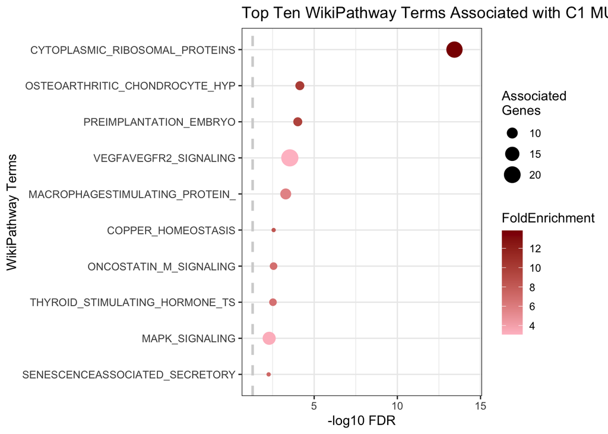

```r
wiki <- temp[temp$collection == 'WikiPathways',] # subsetting to just Wiki results

wiki$id <- gsub('WP_','', wiki$ID) # removing the WP_ preceder from term IDs
wiki$id <- substr(wiki$id,1,30) # limiting to thirty characters for ID bc some get long
wiki$id <- factor(wiki$id, levels = rev(unique(wiki$id))) # ordering them by p-vals

ggplot(wiki[1:10,], # only plotting the first ten
       aes(x = -log10(p.adjust),
           y = id,
           color = FoldEnrichment,
           size = Count)) +
  theme_bw() + # my theme of choice
  geom_point() +
  scale_color_gradient(low = 'pink', high = 'darkred') + # creating a monotonic color scheme
  # creating a significance cutoff to let viewers know all values plotted are significant
  geom_vline(xintercept = -log10(0.05), colour = 'lightgrey', linetype = 2, linewidth = 1) +
  # increasing the xlims because the larger points were getting cut off
  xlim(c(-log10(0.05),-log10(min(wiki$p.adjust)) + 1)) +
  # cleaning up the labels on the graph
  labs(fill = 'Fold\nEnrichment',
       size = 'Associated\nGenes') +
  xlab('-log10 FDR') +
  ylab("WikiPathway Terms") +
  ggtitle("Top Ten WikiPathway Terms Associated with C1 MUT")
```

```r
mut_c1 <- wiki[1:10,] # saving to plot with enriched in MUT
```

### 4.3.3 Plotting Both

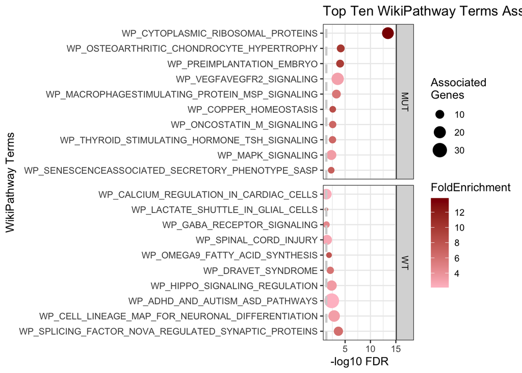

```r
wt_c1$group <- 'WT'
mut_c1$group <- 'MUT'

temp <- rbind(wt_c1,
              mut_c1[10:1,])

temp$id <- factor(temp$ID, levels = unique(temp$ID))

ggplot(temp) + # only plotting the first ten
  facet_grid(rows = vars(group),
             scales = 'free', space = 'free') +
  theme_bw() + # my theme of choice
  geom_point(aes(x = -log10(p.adjust),
           y = id,
           color = FoldEnrichment,
           size = Count)) +
  scale_color_gradient(low = 'pink', high = 'darkred') + # creating a monotonic color scheme
  # creating a significance cutoff to let viewers know all values plotted are significant
  geom_vline(xintercept = -log10(0.05), colour = 'lightgrey', linetype = 2, linewidth = 1) +
  # increasing the xlims because the larger points were getting cut off
  xlim(c(-log10(0.05),-log10(min(wiki$p.adjust)) + 1)) +
  # cleaning up the labels on the graph
  labs(fill = 'Fold\nEnrichment',
       size = 'Associated\nGenes') +
  xlab('-log10 FDR') +
  ylab("WikiPathway Terms") +
  ggtitle("Top Ten WikiPathway Terms Associated with C1")
```